# Module 7 Lecture - Thinking and Intelligence

Introductory Psychology

Quinton Quagliano, M.S., C.S.P

Department of Psychology

# 1 Overview and Introduction

Agenda

1 Overview and Introduction

2 What is Cognition?

3 Language

4 Problem Solving

5 What Is Intelligence

6 Conclusion

## 1.1 Textbook Learning Objectives

- Describe cognition
- Distinguish concepts and prototypes
- Explain the difference between natural and artificial concepts
- Describe how schemata are organized and constructed
- Define language and demonstrate familiarity with the components of language
- Understand the development of language
- Explain the relationship between language and thinking
- Describe problem solving strategies
- Define algorithm and heuristic
- Explain some common roadblocks to effective problem solving and decision making
- Define intelligence
- Explain the triarchic theory of intelligence
- Identify the difference between intelligence theories
- Explain emotional intelligence

## 1.2 Instructor Learning Objectives

- Understand the key vocabulary used in intelligence, language, and cognition theories
- Appreciate the complexity in defining and measuring intelligence
- Understand some of the basic developmental processes in language and intelligence

## 1.3 Introduction

- **Discuss: What does it mean to be 'smart'? How would you define intelligence? Try writing down a definition based off of what you know before going through the rest of lecture**
- **Question: Which of the historical perspectives focused on a study of internal processes, partially popularized by Noam Chomsky?**
- A) Behaviorism
- B) Psychoanalysis
- C) Cognitivism
- D) Functionalism
- Like most of the things we talk about, intelligence is complex - and not necessarily just one clear thing
  - In fact, this lecture will focus on several different theories of how intelligence works
- We will focus on what we sometimes call higher-order cognitive skills, or our ability to think critically, quickly, and problem-solve creatively
  - These are skills that are often associated with how smart we are, but we’ll also talk about how it is difficult to properly measure those things

# 2 What is Cognition?

Agenda

1 Overview and Introduction

2 What is Cognition?

3 Language

4 Problem Solving

5 What Is Intelligence

6 Conclusion

## 2.1 Introduction

- **Important: Cognitive psychology what the hardest psych class for me, your instructor, when I was in undergraduate! Try to lock-in for all this**
- **Cognition**, put another way, is all of the thinking that we do, both those that we are aware of, and those we are not. Generally we might say it deals with:
  - Perception
  - Knowledge
  - Problem solving
  - Judgment
  - Language
  - Memory
  - and many other facets
- Study in this area focus on how we organize both our conscious, but also unconcious thoughts

## 2.2 Diving into Cognition

- Let’s start with some common examples of cognition:
  - You listening to and understanding this lecture
  - You coming up with a list of things to do and planning when to do them on your schedule
  - You deciding what to eat for lunch
  - You choosing the right answer on a test
  - But not all cognition or thinking is done intentionally
- **Discuss: Give me more examples like the ones above, what do you think about in a day?**
- **Cognitive psychology** is a modern subfield of psychology birthed out of cognitivism focused on studying all of the processes like those described above
  - Often scientists like to try and figure out how we organize, understand, and execute on ideas and thoughts
- **Question: Previously in module 3, there was a part of the brain's cortex that I pointed out has a lot to do with decision-making, what part was that?**
- A) Pre-frontal area
- B) Wernicke's area
- C) Broca's area
- D) Hippocampus

## 2.3 Concepts and Prototypes

- As we learned in our modules on senses and perception, we take in a lot of information through our various sensory receptors
- **Discuss: What is a sensory receptor? What specifically would the sensory receptor for the gustatory system be?**
- However, our senses are just the start, once those signals and inputs travel back into the brain, they are integrated with our memories, thoughts, motivations, ideas, and beliefs

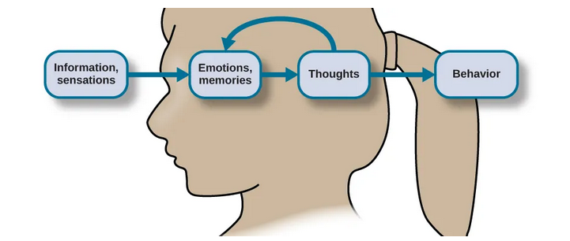

- Our mind needs a way to organize all of this information about our senses, emotions, and thoughts! So we create similar grouping for related things called **concepts**
  - Concepts are all about shared meaning or characteristics between things
- **Important: Concepts are the reason we understand things as being connected, like your understanding of biopsychology and how it plays into learning or intelligence! Often, they are described as the 'building blocks' of our cognition.**
- Concepts are not the same from person to person, even though we may agree on some
  - E.g., people can agree on groups of animals like birds, mammals, etc.
  - But some concepts are more personal, and are not so easy to describe, i.e., they are abstract
- **Prototypes** can be thought of as an “ideal” representative of a concept or group
  - E.g., when I think of “cat” as a concept, a brown tabby housecat appears in my brain, or when I think of “flower”, I envision a sunflower
- **Discuss: For your concept of a 'dog' what do you envision? Describe it here**

## 2.4 Natural and Artificial Concepts

- We classify concepts into one of two categories: natural or artificial
- **Natural concepts** are those that we gather and develop through experiences and exposure and direct observation and first-hand knowledge
  - For example: this could be coming to have a concept of “plants” by seeing and feeling many different plants, reading about them, hearing about them
- **Artificial concepts** are those that are explained and understood by possessing some certain abstract characteristics
  - Example: The concept of a math equation or a shape

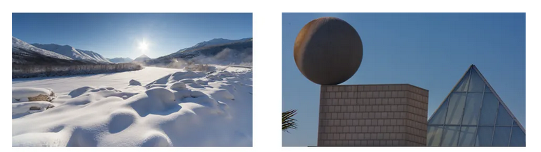

- **Discuss: Based upon the prior explanation, would the concept of 'dog' be better classified as natural or artificial?**

## 2.5 Schemata

- Because concepts are so basic, simple, and limited, we need a way to further organize and use them. **Schemata (plural for schema)** are clusters of related concepts that helps us more quickly apply concepts and derive understanding
- **Important: Schemata help us with efficiency, but are not always accurate, which can get you into a lot of trouble!**
- A **role schema** is that which we apply to people, in classifying what role we think they are likely to perform or what characteristics they are likely to possess
  - Though they may match part of a certain schema, they may not match all of it
  - E.g., you may meet your middle school math teacher at a rock concert, and you are surprised, because that type of music doesn’t mesh with the schema of “math teacher”
- **Discuss: Thing about a way that a 'role schema' could cause interpersonal conflict or drama**
- **Event** schemas are those which are applied to routines or traditions
  - It is a certain procedureapplied to a common situation without any further thought
  - E.g., we have certain ways to greet each other, like a hug or handshake, “Hey, how are you?”
- Schemas are not easy to change, we might even call them habits or tendencies
  - Instructor example: keep reaching to turn the key in a push button start car

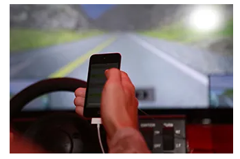

# 3 Language

Agenda

1 Overview and Introduction

2 What is Cognition?

3 Language

4 Problem Solving

5 What Is Intelligence

6 Conclusion

## 3.1 Introduction

- Language is a critical part of communication, though it is not the only way we communicate with one another
- **Question: Review: What part of the temporal cortex deals with receptive language?**
- A) Broca's area
- B) Wernicke's area
- C) Ventral Tegmental Area
- D) Substantia Nigra
- **Important: Like most things in this class, you could just take a whole class on the intersection of psychology and linguistics, called psycholinguistics!**

## 3.2 Components of Language

- There are several parts of language that make up how we communicate
- **Lexicon** is the words and vocabulary of a language, e.g., all the words in the dictionary
  - **Phonemes** are basic sounds produced in a language
  - **Morphemes** are the smallest unit that has some meaning from a combination of phonemes
- **Question: Some indigenous groups in North America are capable of creating phonemes that are not present in the English Lexicon. Research done comparing the languages of indigenous and non-indigenous groups may be described as....**
- A) Developmental
- B) Cross-cultural
- C) Biological
- D) Intuitive
- **Grammar** is the set of rules and conventions a language follows, e.g., what order things go in and the tense of actions
  - Within grammar, we have two further classifications: semantics and syntax
  - **Semantics** is the way we pull meaning from morphemes and words
  - **Syntax** is the way we organize into sentences

## 3.3 Language Development

- There has been serious debate in how language is developed, with folks like B.F. Skinner proposing that language is purely learned by conditioning
- **Discuss: What specific type of conditioning was Skinner most closely associated with and what sort of consequence leads to an increase in future behavior?**
- However, cognitivists and psycholinguists like Noam Chomsky rejected this notion, saying that the answer may very well be more internal and biological
  - It also seems that our brains are most effective at learning language when we are young and that we get progressively worse as we get older
- **Important: This is why it is important that young children get good exposure to language learning early on, as they simply don't maintain that ability to learn as time goes on!**

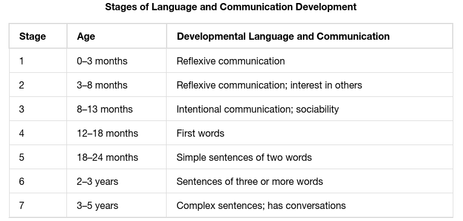

- **Question: During biopsychology, we talked about the ability of the brain to generate new connections and respond to change like damage by modifying connections, but that this ability went down over time - what was that called?**
- A) Adaptability
- B) Responsive change
- C) Breakthrough
- D) Neuroplasticity

# 4 Problem Solving

Agenda

1 Overview and Introduction

2 What is Cognition?

3 Language

4 Problem Solving

5 What Is Intelligence

6 Conclusion

## 4.1 Introduction

- **Important: I've got 99 problems: student loans and rent are about 50 of those. I'm sure you all can relate.**
- Life presents us with many simple and difficult problems to recognize and attempt to solve
  - These problems may not even appear problematic: scheduling something is technically still a problem to be solved

## 4.2 Strategies for Problem Solving

- As the name implies, **problem-solving strategies** are procedures we use to approach fixing situations

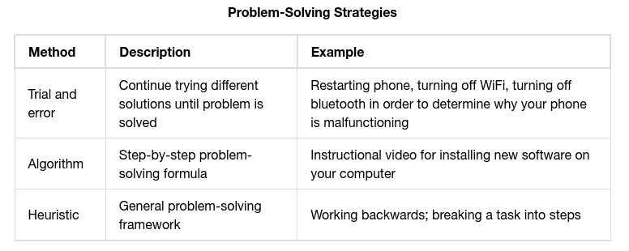

- **Discuss: We hear a lot about 'algorithms' regarding social media, how does that connect to the above description?**
- **Heuristics** are cognitive shortcut strategies help us save time and processing energy
  - However, they sometimes lead us to the wrong conclusion or solution
- **Question: Earlier, we described another part of our cognition's organization that contributes to speediness in processing, what was that?**
- A) Phonemes
- B) Lexicons
- C) Schemata
- D) None of the above
- Heuristics tend to be used to save energy often under one of these circumstances:
  - When one is faced with too much information
  - When the time to make a decision is limited
  - When the decision to be made is unimportant
  - When there is access to very little information to use in making the decision
  - When an appropriate heuristic happens to come to mind in the same moment
- **Important: To try and help understand the difference between a schema and a heuristic: a schema is a way to classify or describe something, a heuristic is a way to approach a problem.**

## 4.3 Problems in Problem Solving

- Of course, we don’t always get things right!
- We call it a **mental set** when repeatedly attempting to use a previous solution that no longer works to solve a problem
  - **Functional fixedness** is when we have a mental set related to our perception of what a certain thing is usually used for and cannot innovate or creatively use it differently

> Insanity is doing the same thing over and over again and expecting different results
- The **Anchoring bias** is the tendency to hyperfixate on one part of a complex problem, i.e., you “anchor” on a single a don’t budge off it
- The **confirmation bias** is the tendency to selectively seek out information that supports your prior held beliefs
- **Important: Confirmation bias is perhaps maybe one of the most prevalent issues that prevent reasonable discourse in politics.**
- The **hindsight bias** makes you think you could have prevented an event that really you couldn’t have

> Hindsight is 20/20
- The **Representative bias** is the tendency to believe that each individual member of a certain group behaves in a way in line with your pre-defined schema for that group
  - E.g., All professors like to read books in their spare time, so my professor must like to do the same

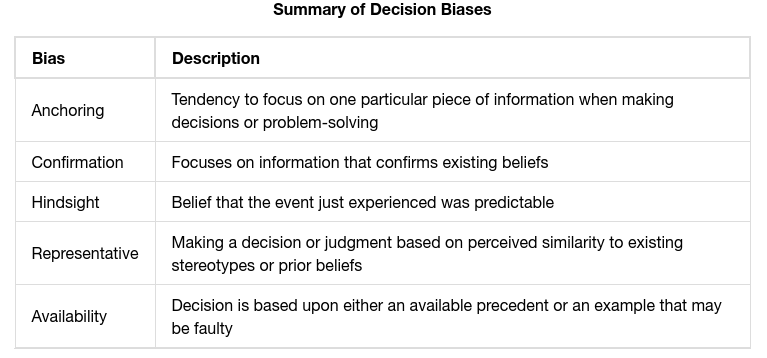

- **Question: Billy only reads opinion articles from his favorite podcaster, because he often agrees with what that podcaster has to say - what bias is likely at play here?**
- A) Hindsight
- B) Confirmation
- C) Anchoring
- D) Representative

# 5 What Is Intelligence

Agenda

1 Overview and Introduction

2 What is Cognition?

3 Language

4 Problem Solving

5 What Is Intelligence

6 Conclusion

## 5.1 Introduction

- Intelligence has been hotly debated as a topic of interest among psychological researchers for a long time
- **Discuss: If I said that intelligence testing is often used in the subfield of psychology focused on diagnosis and treatment of abnormal psychological conditions, what subfield would this be?**

## 5.2 Early Views on Intelligence

- The earliest perspectives on intelligence largely held that intelligence, while maybe composed of several parts, could be summarized under one central composite
- E.g., Charles Spearman $g \rightarrow$ general factor, Aristotle
- Later on, researchers like Raymond Cattell proposed a separation of two types of intelligence:
  - **Crystallized intelligence** was our ability to acquire and retrieve knowledge, or anything related to our memory and ability to retain
    - E.g., remembering a long phone number just read to you in order to write it down moments later, remembering the definition of a word you’ve read in a book
  - **Fluid intelligence** is our ability to solve complex patterns and relationships
    - E.g., finding where a puzzle piece goes, figuring out how to balance an algebra equation
- **Question: A psychologist is testing a young adult, and asks him to point to a picture of a lion, out of 10 possible options - which type of intelligence is this loading on to?**
- A) Crystallized intelligence
- B) Fluid intelligence
- C) Neither of these
- D) Both of these

## 5.3 More Modern Views

- Robert Sternberg proposed the **triarchic theory of intelligence**

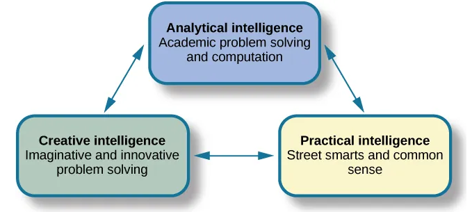

- Howard Gardner came up with the **Multiple Intelligences Theory** where each person has several types of intelligence:
  - Linguistic
  - Logical-mathematical
  - Musical
  - Bodily kinesthetic
  - Spatial
  - Interpersonal
  - Intrapersonal
  - Naturalistic
- **Discuss: Gardner's ideas catch a lot of criticism for lacking in empiricism - what does this mean?**
- The most recent accepted view is the **Cattell-Horn-Carroll (CHC) Theory of Cognitive Abilities** that views intelligence as existing as a heirarchy of related abilities that can only be measured with specific tests and generalized to larger abilities
  - Integrates the views of Spearman, Cattell, some aspects of Gardner and Sternberg
- Example of CHC Theory in Practice: WAIS Test - Full Scale Intelligence Quotient above…
  - Fluid Reasoning - MR, FW subtests
  - Verbal Comprehension - SI, VC subtests
  - Visual Spatial - BD, VP subtests
  - Processing Speed - SS, CD subtests
  - Working Memory - DQ, RD subtsests

# 6 Conclusion

Agenda

1 Overview and Introduction

2 What is Cognition?

3 Language

4 Problem Solving

5 What Is Intelligence

6 Conclusion

## 6.1 Recap

- Our cognition is rather complex, with many organizational processes and shortcuts working to help us make sense of complex environments
- While our brain works to conserve energy and act in a way the prioritizes efficiency, that can lead to mistakes in our perceptions and classification
- Intelligence is a complex idea that tries to summarize our relative cognitive abilities in different domains, and the concept of this has evolved several times throughout history to arrive at the modern-day CHC theory

## 6.2 Lecture Check-in

- Make sure to complete and submit the lecture check-in

[figure not shown]

Module 7 Lecture - Thinking and Intelligence || Introductory Psychology